# Assignment-1

**Execute the following cell to load the tidyverse library:**

```r
library(tidyverse)
```

**Execute the following cell to load the data. Refer to this website http://archive.ics.uci.edu/ml/datasets/Auto+MPG for details on the dataset:**

```r
autompg = read.table(
  "http://archive.ics.uci.edu/ml/machine-learning-databases/auto-mpg/auto-mpg.data",
  quote = "\"",
  comment.char = "",
  stringsAsFactors = FALSE)
head(autompg,20)
```

|  | V1 | V2 | V3 | V4 | V5 | V6 | V7 | V8 | V9 |
| --- | --- | --- | --- | --- | --- | --- | --- | --- | --- |
| 1 | 18 | 8 | 307 | 130.0 | 3504 | 12.0 | 70 | 1 | chevrolet chevelle malibu |
| 2 | 15 | 8 | 350 | 165.0 | 3693 | 11.5 | 70 | 1 | buick skylark 320 |
| 3 | 18 | 8 | 318 | 150.0 | 3436 | 11.0 | 70 | 1 | plymouth satellite |
| 4 | 16 | 8 | 304 | 150.0 | 3433 | 12.0 | 70 | 1 | amc rebel sst |
| 5 | 17 | 8 | 302 | 140.0 | 3449 | 10.5 | 70 | 1 | ford torino |
| 6 | 15 | 8 | 429 | 198.0 | 4341 | 10.0 | 70 | 1 | ford galaxie 500 |
| 7 | 14 | 8 | 454 | 220.0 | 4354 | 9.0 | 70 | 1 | chevrolet impala |
| 8 | 14 | 8 | 440 | 215.0 | 4312 | 8.5 | 70 | 1 | plymouth fury iii |
| 9 | 14 | 8 | 455 | 225.0 | 4425 | 10.0 | 70 | 1 | pontiac catalina |
| 10 | 15 | 8 | 390 | 190.0 | 3850 | 8.5 | 70 | 1 | amc ambassador dpl |

[output cut: 10 more lines]

**Question 1.1**: print the structure of the unedited data set. How many samples and features are there? Ans - 398 samples and 9 features.

```r
str(autompg)
```

```
'data.frame':   398 obs. of  9 variables:
 $ V1: num  18 15 18 16 17 15 14 14 14 15 ...
 $ V2: int  8 8 8 8 8 8 8 8 8 8 ...
 $ V3: num  307 350 318 304 302 429 454 440 455 390 ...
 $ V4: chr  "130.0" "165.0" "150.0" "150.0" ...
 $ V5: num  3504 3693 3436 3433 3449 ...
 $ V6: num  12 11.5 11 12 10.5 10 9 8.5 10 8.5 ...
 $ V7: int  70 70 70 70 70 70 70 70 70 70 ...
 $ V8: int  1 1 1 1 1 1 1 1 1 1 ...
 $ V9: chr  "chevrolet chevelle malibu" "buick skylark 320" "plymouth satellite" "amc rebel sst" ...
```

**Execute the following cell to assign names to the columns of the dataframe:**

```r
colnames(autompg) = c("mpg", "cyl", "disp", "hp", "wt", "acc", "year", "origin", "name")
str(autompg) # Validate the result
```

```
'data.frame':   398 obs. of  9 variables:
 $ mpg   : num  18 15 18 16 17 15 14 14 14 15 ...
 $ cyl   : int  8 8 8 8 8 8 8 8 8 8 ...
 $ disp  : num  307 350 318 304 302 429 454 440 455 390 ...
 $ hp    : chr  "130.0" "165.0" "150.0" "150.0" ...
 $ wt    : num  3504 3693 3436 3433 3449 ...
 $ acc   : num  12 11.5 11 12 10.5 10 9 8.5 10 8.5 ...
 $ year  : int  70 70 70 70 70 70 70 70 70 70 ...
 $ origin: int  1 1 1 1 1 1 1 1 1 1 ...
 $ name  : chr  "chevrolet chevelle malibu" "buick skylark 320" "plymouth satellite" "amc rebel sst" ...
```

**Question 1.2**: complete the code segment below to remove samples with missing horsepower (hp) values represented as a “?” in the dataset.

```r
autompg = autompg %>% filter(!(hp == '?'))
autompg %>% filter(hp == '?') # Validate the result
```

| mpg | cyl | disp | hp | wt | acc | year | origin | name |
| --- | --- | --- | --- | --- | --- | --- | --- | --- |

**Question 1.3**: complete the code segment below to remove samples with the name “plymouth reliant”

```r
autompg = autompg %>% filter(!(name == 'plymouth reliant'))
autompg %>% filter((name == 'plymouth reliant')) # Validate the result
```

| mpg | cyl | disp | hp | wt | acc | year | origin | name |
| --- | --- | --- | --- | --- | --- | --- | --- | --- |

**Question 2.1**: complete the code segment below to select all features except ‘name’

```r
autompg = autompg %>% select(-name)
str(autompg) # Validate the result
```

```
'data.frame':   390 obs. of  8 variables:
 $ mpg   : num  18 15 18 16 17 15 14 14 14 15 ...
 $ cyl   : int  8 8 8 8 8 8 8 8 8 8 ...
 $ disp  : num  307 350 318 304 302 429 454 440 455 390 ...
 $ hp    : chr  "130.0" "165.0" "150.0" "150.0" ...
 $ wt    : num  3504 3693 3436 3433 3449 ...
 $ acc   : num  12 11.5 11 12 10.5 10 9 8.5 10 8.5 ...
 $ year  : int  70 70 70 70 70 70 70 70 70 70 ...
 $ origin: int  1 1 1 1 1 1 1 1 1 1 ...
```

**Execute the following cell to change the type of hp values from character to numeric:**

```r
autompg$hp = as.numeric(autompg$hp)
str(autompg) # Validate that type has changed from chr to num for hp
```

```
'data.frame':   390 obs. of  8 variables:
 $ mpg   : num  18 15 18 16 17 15 14 14 14 15 ...
 $ cyl   : int  8 8 8 8 8 8 8 8 8 8 ...
 $ disp  : num  307 350 318 304 302 429 454 440 455 390 ...
 $ hp    : num  130 165 150 150 140 198 220 215 225 190 ...
 $ wt    : num  3504 3693 3436 3433 3449 ...
 $ acc   : num  12 11.5 11 12 10.5 10 9 8.5 10 8.5 ...
 $ year  : int  70 70 70 70 70 70 70 70 70 70 ...
 $ origin: int  1 1 1 1 1 1 1 1 1 1 ...
```

**Question 2.2**: complete the code cell to modify ‘origin’ column to reflect local (1) and international models (0)

```r
autompg = autompg %>% mutate(origin = ifelse(origin == 1, 'local', 'international'))
head(autompg, 20)
```

|  | mpg | cyl | disp | hp | wt | acc | year | origin |
| --- | --- | --- | --- | --- | --- | --- | --- | --- |
| 1 | 18 | 8 | 307 | 130 | 3504 | 12.0 | 70 | local |
| 2 | 15 | 8 | 350 | 165 | 3693 | 11.5 | 70 | local |
| 3 | 18 | 8 | 318 | 150 | 3436 | 11.0 | 70 | local |
| 4 | 16 | 8 | 304 | 150 | 3433 | 12.0 | 70 | local |
| 5 | 17 | 8 | 302 | 140 | 3449 | 10.5 | 70 | local |
| 6 | 15 | 8 | 429 | 198 | 4341 | 10.0 | 70 | local |
| 7 | 14 | 8 | 454 | 220 | 4354 | 9.0 | 70 | local |
| 8 | 14 | 8 | 440 | 215 | 4312 | 8.5 | 70 | local |
| 9 | 14 | 8 | 455 | 225 | 4425 | 10.0 | 70 | local |
| 10 | 15 | 8 | 390 | 190 | 3850 | 8.5 | 70 | local |

[output cut: 10 more lines]

**Question 2.3**: print the structure of the dataframe. What types are the columns ‘cyl’ and ‘origin’? Ans - ‘cyl’ is type int and ‘origin’ is type chr.

```r
str(autompg)
```

```
'data.frame':   390 obs. of  8 variables:
 $ mpg   : num  18 15 18 16 17 15 14 14 14 15 ...
 $ cyl   : int  8 8 8 8 8 8 8 8 8 8 ...
 $ disp  : num  307 350 318 304 302 429 454 440 455 390 ...
 $ hp    : num  130 165 150 150 140 198 220 215 225 190 ...
 $ wt    : num  3504 3693 3436 3433 3449 ...
 $ acc   : num  12 11.5 11 12 10.5 10 9 8.5 10 8.5 ...
 $ year  : int  70 70 70 70 70 70 70 70 70 70 ...
 $ origin: chr  "local" "local" "local" "local" ...
```

**Question 3.1**: complete the code segment below to change the types of ‘cyl’ and ‘origin’ columns to factor

```r
 catcols = c('cyl', 'origin')
 autompg[catcols] = lapply(autompg[catcols], as.factor)
 str(autompg) # Validate the change
```

```
'data.frame':   390 obs. of  8 variables:
 $ mpg   : num  18 15 18 16 17 15 14 14 14 15 ...
 $ cyl   : Factor w/ 5 levels "3","4","5","6",..: 5 5 5 5 5 5 5 5 5 5 ...
 $ disp  : num  307 350 318 304 302 429 454 440 455 390 ...
 $ hp    : num  130 165 150 150 140 198 220 215 225 190 ...
 $ wt    : num  3504 3693 3436 3433 3449 ...
 $ acc   : num  12 11.5 11 12 10.5 10 9 8.5 10 8.5 ...
 $ year  : int  70 70 70 70 70 70 70 70 70 70 ...
 $ origin: Factor w/ 2 levels "international",..: 2 2 2 2 2 2 2 2 2 2 ...
```

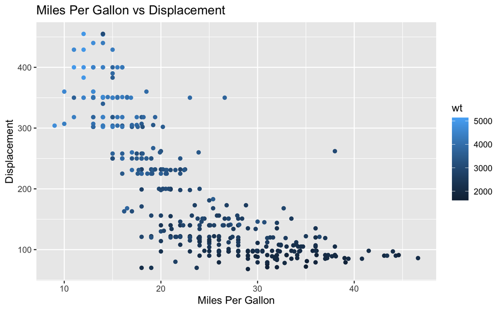

```r
p = ggplot(data = autompg, aes(x = mpg, y = disp, color = wt)) +
             geom_point() +
             labs(x = 'Miles Per Gallon', y = 'Displacement', title = 'Miles Per Gallon vs Displacement')
p
```